# EDA, linear regression, and predictive modeling on population groups by shelter-cost-to-income ratio and core housing need.

Zeliha Ural Merpez September 4, 2025

This project explores population groups in Ontario’s census subdivisions using Statistics Canada's [dataset](https://www150.statcan.gc.ca/t1/tbl1/en/tv.action?pid=9810062401&pickMembers%5B0%5D=1.2265&pickMembers%5B1%5D=2.1&pickMembers%5B2%5D=3.1&pickMembers%5B3%5D=4.1&pickMembers%5B4%5D=5.1) on shelter-cost-to-income ratios and core housing need. The goal is to apply exploratory data analysis, regression modeling, and predictive techniques to understand how housing affordability impacts different demographic groups.

By analyzing this dataset, we aim to uncover patterns and relationships between income levels, shelter costs, and housing adequacy—providing insights into the factors contributing to core housing need across Ontario.

[figure not shown]

**Summary**

The analysis includes four key steps: exploratory data analysis, data preprocessing and feature engineering, fitting and evaluating a Poisson regression model, and interpreting results through detailed model summaries and visualizations.

**Steps:**

- Exploratory Data Analysis
- Feature Engineering
- Poisson Regression Modeling & Summary Interpretation
- Results Visualization

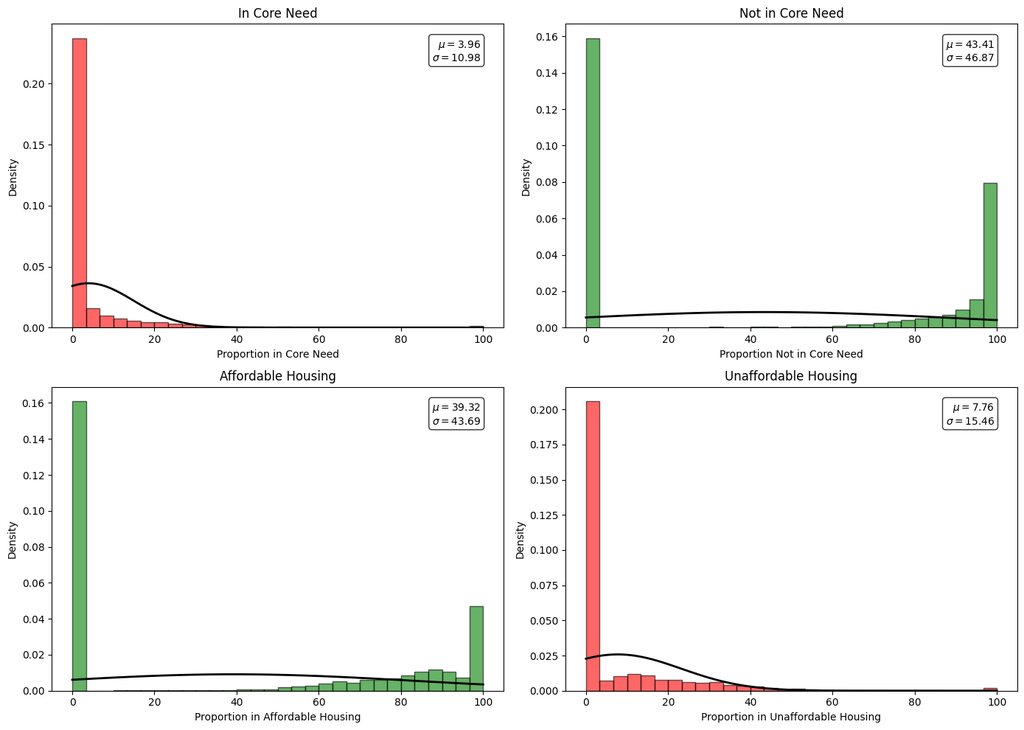

### Interpreting the Histograms

The figure above shows the distribution of percentages for:

- **In Core Housing Need**
- **Not in Core Housing Need**
- **Affordable Housing**
- **Unaffordable Housing**

Each variable has been normalized within its respective subgroup and expressed as a percentage (0–100%).

### Key Observations

- **Distributions are not normal:** None of the four indicators follow a normal distribution. This is evident from the sharp peaks near 0 or 100 and the long tails in the histograms.
- **Heavy clustering at 0%:**
  - All four distributions show a high number of observations at 0%.
  - This occurs because many **census subdivisions report no data** for certain population groups (e.g., smaller visible minority groups, specific age brackets), resulting in a valid percentage of **zero**.
- **Right-skewed distributions:**
  - **In Core Need** and **Unaffordable Housing** are strongly **right-skewed**, with most values near 0% and a few high outliers.
  - This indicates that **only a small number of subdivisions** have high percentages of households in need or living in unaffordable housing.
- **Left-skewed or bimodal distributions:**
  - **Not in Core Need** and **Affordable Housing** have more dispersed values, with many subdivisions near **100%**, and others at or near 0%.
  - This leads to **left-skewed** or even **bimodal** shapes, reflecting stark differences in housing adequacy across regions.

### What This Tells Us

- The skewed and non-normal distributions emphasize the **inequality** in housing conditions across Ontario’s census subdivisions.
- Some areas show **almost universal access** to affordable housing or lack of core housing need, while others reflect **acute challenges**.
- These patterns are shaped by **demographics, geography, and housing stock availability**, and must be considered in modeling or policy targeting.

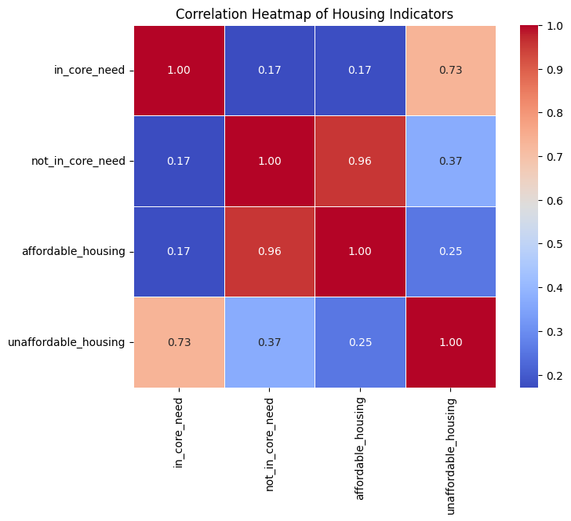

The correlation heatmap reveals interesting relationships among the four housing indicators. There is a strong positive correlation (0.96) between not in core need and affordable housing, suggesting that areas with more affordable housing tend to have fewer households in core housing need. Conversely, in core need shows a high positive correlation (0.73) with unaffordable housing, indicating that higher unaffordability is associated with greater housing need. The weaker correlations between other pairs highlight distinct dynamics between affordability and housing need categories across different regions. These insights can guide targeted housing policy and resource allocation.

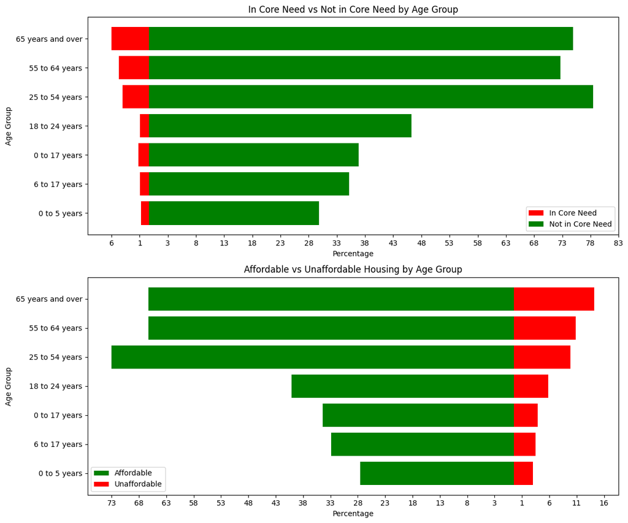

```
                 Generalized Linear Model Regression Results
==============================================================================
Dep. Variable:                      y   No. Observations:                66024
Model:                            GLM   Df Residuals:                    65965
Model Family:                 Poisson   Df Model:                           58
Link Function:                    Log   Scale:                          1.0000
Method:                          IRLS   Log-Likelihood:            -2.6990e+05
Date:                Thu, 04 Sep 2025   Deviance:                   4.8607e+05
Time:                        13:46:05   Pearson chi2:                 1.32e+06
No. Iterations:                     7   Pseudo R-squ. (CS):             0.9870
Covariance Type:            nonrobust
=========================================================================================================================================
                                                                            coef    std err          z      P>|z|      [0.025      0.975]
-----------------------------------------------------------------------------------------------------------------------------------------
const                                                                    -0.3642      0.021    -17.454      0.000      -0.405      -0.323
gender_Women+                                                             0.2348      0.005     51.384      0.000       0.226       0.244
tenure_Owner                                                             -1.1731      0.009   -134.862      0.000      -1.190      -1.156
tenure_Renter                                                             0.1021      0.006     17.511      0.000       0.091       0.114
tenure_Subsidized housing                                                -0.4551      0.007    -67.062      0.000      -0.468      -0.442
tenure_With mortgage                                                     -1.2956      0.009   -142.046      0.000      -1.313      -1.278
tenure_Without mortgage                                                  -1.9112      0.012   -162.247      0.000      -1.934      -1.888
maintainer_Total - Household maintainer                                   0.3808      0.005     82.421      0.000       0.372       0.390
population_char_0 to 5 years                                             -0.3350      0.012    -27.907      0.000      -0.358      -0.311
population_char_18 to 24 years                                           -0.2839      0.012    -24.001      0.000      -0.307      -0.261
population_char_25 to 54 years                                            0.8318      0.009     89.573      0.000       0.814       0.850
population_char_55 to 64 years                                            0.9568      0.009    104.928      0.000       0.939       0.975
population_char_6 to 17 years                                            -0.1445      0.011    -12.699      0.000      -0.167      -0.122
population_char_65 years and over                                         1.2343      0.009    140.148      0.000       1.217       1.252
SSM_City of Brantford                                                     2.0192      0.028     72.477      0.000       1.965       2.074
SSM_City of Cornwall                                                      0.8168      0.027     29.720      0.000       0.763       0.871
SSM_City of Hamilton                                                      2.5594      0.029     87.996      0.000       2.502       2.616
SSM_City of Kawartha Lakes                                                1.3410      0.026     51.176      0.000       1.290       1.392
SSM_City of Kingston                                                      1.1989      0.027     44.147      0.000       1.146       1.252
SSM_City of London                                                        0.8785      0.025     34.526      0.000       0.829       0.928
SSM_City of Ottawa                                                        2.5877      0.029     89.697      0.000       2.531       2.644
SSM_City of St. Thomas                                                    0.5184      0.029     18.021      0.000       0.462       0.575
SSM_City of Stratford                                                     0.7448      0.029     25.434      0.000       0.687       0.802
SSM_City of Toronto                                                       2.8588      0.027    106.647      0.000       2.806       2.911
SSM_City of Windsor                                                       1.4596      0.023     62.900      0.000       1.414       1.505
SSM_County of Bruce                                                       0.6278      0.028     22.502      0.000       0.573       0.682
```

[output cut: 19 more lines]

```
SSM_Manitoulin-Sudbury District Services Board                           -0.0043      0.027     -0.156      0.876      -0.058       0.050
SSM_Municipality of Chatham-Kent                                          1.8631      0.037     50.868      0.000       1.791       1.935
SSM_Norfolk County                                                        1.7717      0.030     59.225      0.000       1.713       1.830
SSM_Rainy River District Social Services Administration Board            -0.8103      0.044    -18.377      0.000      -0.897      -0.724
SSM_Regional Municipality of Durham                                       2.2456      0.021    107.317      0.000       2.205       2.287
SSM_Regional Municipality of Halton                                       2.4290      0.022    109.303      0.000       2.385       2.473
SSM_Regional Municipality of Niagara                                      1.9033      0.021     91.498      0.000       1.863       1.944
SSM_Regional Municipality of Peel                                         2.6173      0.023    116.061      0.000       2.573       2.661
SSM_Regional Municipality of Waterloo                                     1.7705      0.023     78.518      0.000       1.726       1.815
SSM_Regional Municipality of York                                         2.4726      0.020    121.622      0.000       2.433       2.512
SSM_The City of Peterborough                                              1.1672      0.024     48.729      0.000       1.120       1.214
SSM_Thunder Bay District Social Services Administration Board             0.0804      0.027      2.945      0.003       0.027       0.134
SSM_United Counties of Leeds & Grenville                                  0.6358      0.025     25.683      0.000       0.587       0.684
SSM_United Counties of Prescott & Russell                                 1.1434      0.025     46.398      0.000       1.095       1.192
=========================================================================================================================================
```

| Feature | Coefficient | exp(coef) | % Change | Significant |
| --- | --- | --- | --- | --- |
| const | -0.3642 | 0.695 | 30.5% ↓ | Yes |
| gender_Women+ | 0.2348 | 1.265 | 26.5% ↑ | Yes |
| tenure_Owner | -1.1731 | 0.309 | 69.1% ↓ | Yes |
| tenure_Renter | 0.1021 | 1.107 | 10.7% ↑ | Yes |
| tenure_Subsidized housing | -0.4551 | 0.634 | 36.6% ↓ | Yes |
| tenure_With mortgage | -1.2956 | 0.274 | 72.6% ↓ | Yes |
| tenure_Without mortgage | -1.9112 | 0.148 | 85.2% ↓ | Yes |
| maintainer_Total - Household maintainer | 0.3808 | 1.463 | 46.3% ↑ | Yes |
| population_char_0 to 5 years | -0.335 | 0.715 | 28.5% ↓ | Yes |
| population_char_18 to 24 years | -0.2839 | 0.753 | 24.7% ↓ | Yes |
| population_char_25 to 54 years | 0.8318 | 2.297 | 129.7% ↑ | Yes |
| population_char_55 to 64 years | 0.9568 | 2.603 | 160.3% ↑ | Yes |
| population_char_6 to 17 years | -0.1445 | 0.865 | 13.5% ↓ | Yes |
| population_char_65 years and over | 1.2343 | 3.436 | 243.6% ↑ | Yes |
| SSM_City of Brantford | 2.0192 | 7.532 | 653.2% ↑ | Yes |
| SSM_City of Cornwall | 0.8168 | 2.263 | 126.3% ↑ | Yes |
| SSM_City of Hamilton | 2.5594 | 12.928 | 1192.8% ↑ | Yes |
| SSM_City of Kawartha Lakes | 1.341 | 3.823 | 282.3% ↑ | Yes |
| SSM_City of Kingston | 1.1989 | 3.316 | 231.6% ↑ | Yes |
| SSM_City of London | 0.8785 | 2.407 | 140.7% ↑ | Yes |
| SSM_City of Ottawa | 2.5877 | 13.299 | 1229.9% ↑ | Yes |
| SSM_City of St. Thomas | 0.5184 | 1.679 | 67.9% ↑ | Yes |
| SSM_City of Stratford | 0.7448 | 2.106 | 110.6% ↑ | Yes |
| SSM_City of Toronto | 2.8588 | 17.441 | 1644.1% ↑ | Yes |
| SSM_City of Windsor | 1.4596 | 4.304 | 330.4% ↑ | Yes |
| SSM_County of Bruce | 0.6278 | 1.873 | 87.3% ↑ | Yes |
| SSM_County of Dufferin | 0.6559 | 1.927 | 92.7% ↑ | Yes |
| SSM_County of Grey | 0.7644 | 2.148 | 114.8% ↑ | Yes |
| SSM_County of Hastings | 0.688 | 1.99 | 99.0% ↑ | Yes |
| SSM_County of Huron | 0.6486 | 1.913 | 91.3% ↑ | Yes |
| SSM_County of Lambton | 0.7024 | 2.019 | 101.9% ↑ | Yes |
| SSM_County of Lanark | 0.8529 | 2.346 | 134.6% ↑ | Yes |
| SSM_County of Lennox & Addington | 1.6994 | 5.471 | 447.1% ↑ | Yes |
| SSM_County of Northumberland | 1.2757 | 3.581 | 258.1% ↑ | Yes |
| SSM_County of Oxford | 0.5836 | 1.792 | 79.2% ↑ | Yes |
| SSM_County of Renfrew | 0.5172 | 1.677 | 67.7% ↑ | Yes |
| SSM_County of Simcoe | 1.8171 | 6.154 | 515.4% ↑ | Yes |
| SSM_County of Wellington | 1.3622 | 3.905 | 290.5% ↑ | Yes |
| SSM_District Municipality of Muskoka | 1.7387 | 5.69 | 469.0% ↑ | Yes |
| SSM_District of Cochrane Social Service Administration Board | 0.5106 | 1.666 | 66.6% ↑ | Yes |
| SSM_District of Nipissing Social Services Administration Board | 0.7535 | 2.124 | 112.4% ↑ | Yes |
| SSM_District of Parry Sound Social Services Administration Board | 0.3524 | 1.422 | 42.2% ↑ | Yes |
| SSM_District of Sault Ste. Marie Social Services Administration Board | 1.2612 | 3.53 | 253.0% ↑ | Yes |
| SSM_District of Timiskaming Social Services Administration Board | -0.9594 | 0.383 | 61.7% ↓ | Yes |
| SSM_Kenora District Services Board | 0.5429 | 1.721 | 72.1% ↑ | Yes |
| SSM_Manitoulin-Sudbury District Services Board | -0.0043 | 0.996 | 0.4% ↓ | No |
| SSM_Municipality of Chatham-Kent | 1.8631 | 6.444 | 544.4% ↑ | Yes |
| SSM_Norfolk County | 1.7717 | 5.881 | 488.1% ↑ | Yes |
| SSM_Rainy River District Social Services Administration Board | -0.8103 | 0.445 | 55.5% ↓ | Yes |
| SSM_Regional Municipality of Durham | 2.2456 | 9.446 | 844.6% ↑ | Yes |
| SSM_Regional Municipality of Halton | 2.429 | 11.348 | 1034.8% ↑ | Yes |
| SSM_Regional Municipality of Niagara | 1.9033 | 6.708 | 570.8% ↑ | Yes |
| SSM_Regional Municipality of Peel | 2.6173 | 13.699 | 1269.9% ↑ | Yes |
| SSM_Regional Municipality of Waterloo | 1.7705 | 5.874 | 487.4% ↑ | Yes |
| SSM_Regional Municipality of York | 2.4726 | 11.853 | 1085.3% ↑ | Yes |
| SSM_The City of Peterborough | 1.1672 | 3.213 | 221.3% ↑ | Yes |
| SSM_Thunder Bay District Social Services Administration Board | 0.0804 | 1.084 | 8.4% ↑ | Yes |
| SSM_United Counties of Leeds & Grenville | 0.6358 | 1.889 | 88.9% ↑ | Yes |
| SSM_United Counties of Prescott & Russell | 1.1434 | 3.137 | 213.7% ↑ | Yes |

```
# Notes on Interpretation:
- Coefficients represent the **effect relative to the baseline category** for each categorical variable.
- For example:
  - `gender_Women+` coefficient shows the effect of being Women **compared to the baseline gender** (likely Men or other).
  - `tenure_Owner`, `tenure_Renter`, etc. are effects relative to the base tenure category (e.g., "No tenure" or whichever category is excluded).
  - `SSM_` prefixed features represent effects of different Service Management areas relative to the baseline region (the omitted category).
- The `% Change` column shows how much the odds/risk increase (↑) or decrease (↓) relative to the base category.
- The `Significant` column marks whether the coefficient is statistically significant (p-value < 0.05).
```

## Poisson Regression Summary: Predicting Core Housing Need

This summary shows how different characteristics affect the likelihood of being in **core housing need**, based on a statistical model.

### Base Group (Reference Person)

All comparisons below are relative to a person who is:

- **Male**
- **Lives in non-subsidized housing**
- **Primary household maintainer**
- **Aged 0–17 years**
- **Located in Algoma**

### Key Effects Summary

| Feature | Compared To | Effect Direction | % Change (exp(coef)) | Explanation |
| --- | --- | --- | --- | --- |
| **Gender: Women** | Men | ↑ Higher | **26.5% higher** | Women are 26.5% more likely to be in core housing need. |
| **Tenure: Owner** | Not subsidized housing | ↓ Lower | **69.1% lower** | Homeowners are much less likely to be in core housing need. |
| **Tenure: Renter** | Not subsidized housing | ↑ Slightly Higher | **10.7% higher** | Slight increase compared to base group. |
| **Tenure: Subsidized housing** | Not subsidized housing | ↓ Lower | **36.6% lower** | Subsidized tenants are less likely than other renters. |
| **Tenure: With mortgage** | Not subsidized housing | ↓ Much Lower | **72.6% lower** | Owning with a mortgage significantly reduces likelihood. |
| **Tenure: Without mortgage** | Not subsidized housing | ↓ Very Low | **85.0% lower** | Owning outright is associated with very low risk. |
| **Maintainer: All** | Primary maintainer | ↑ Higher | **46.3% higher** | Households with multiple maintainers face higher need. |
| **Age Group: 0–5 yrs** | 0–17 years | ↓ Lower | **28.5% lower** | Households with very young children face less need. |
| **Age Group: 18–24 yrs** | 0–17 years | ↓ Lower | **24.8% lower** | Households with young adults also have reduced need. |
| **Age Group: 25–54 yrs** | 0–17 years | ↑ Higher | **130.0% higher** | Working-age adults have a notably higher likelihood. |
| **Age Group: 55–64 yrs** | 0–17 years | ↑ Higher | **160.5% higher** | Pre-retirement adults are at high risk. |
| **Age Group: 65+ yrs** | 0–17 years | ↑ Much Higher | **243.6% higher** | Seniors face the highest risk of core housing need. |

### Regional Variation (Selected)

[output not shown]

### Example Scenario

> A **woman aged 65+ living in Toronto in subsidized housing** is **more than 2,400%** more likely to be in core housing need than a **17-year-old male, primary household maintainer living in Algoma**.

### Appendix: How Percentages Were Calculated

The model output uses log-transformed coefficients. To convert:

```
import numpy as np
exp_coef = np.exp(coef)
percentage_change = (exp_coef - 1) * 100
```